# Predicting Grades

## Question

Can we predict whether a Math 325 student will get an A using the scores from assignments during the semester?

## Model Selection

After looking at a pairs plot and adding different variables to the model, it seemed to me that AnalysisTotal was a good place to start. That model has an AIC value of 66.879.

I also suspected that FinalExam was going to play a large role in the final grade. Just adding the FinalExam to the model decreases AIC to 50.983, but I found that if I added a boolean column to the dataset to indicate whether the FinalExam score was “good” or not decreased AIC to 36.88. A “good” final exam value is above 8 for the purposes of my model, which I found mostly by trial and error.

Additionally, I decided to check the number of missing assignments by counting how many zeros were found in the students grades. I suspected that zeros themselves will not only impact that grade directly, but is a further indication of potential knowledge gaps that result from not even attempting an assignment, and that the grade would be impacted indirectly. It didn’t affect it as much as I was expecting, as there seems to be students who skip assignments yet are still able to obtain the coveted ‘A’ grade. Adding a column to the model that indicates whether a student missed more than 4 assignments bumped AIC down to 33.839.

The selected model:

$$P(Y_i = 1|x_i) = \frac{e^{-76.8746+1.9686x_\text{1i} + 24.1343x_\text{2i} - 19.6663x_\text{3i}}}{1+e^{-76.876+1.9686x_\text{1i} + 24.1343x_\text{2i} - 19.6663x_\text{3i}}} = \pi_i$$

$$x_\text{1i} = \text{AnalysisTotal} \\
x_\text{2i} = \text{Good Final Exam Score} \\
x_\text{3i} = \text{More than 4 missing assignments}$$

## Interpretation

```r
grades <- raw_grades %>%
  mutate(zero_count = rowSums(. == 0)) %>%
  mutate(zeros_four_or_greater = zero_count > 4) %>%
  mutate(no_project_1 = ifelse(Project1 == 0, 1, 0)) %>%
  mutate(good_final = FinalExam > 8) %>%
  mutate(zeros_four_or_greater = as.factor(zeros_four_or_greater))

grades$Y <- grades$FinalGrade == 'A'

grades.glm <- glm(Y ~ AnalysisTotal + good_final + zeros_four_or_greater, data = grades, family = binomial)


b <- coef(grades.glm)
```

```r
summary(grades.glm)
```

```
##
## Call:
## glm(formula = Y ~ AnalysisTotal + good_final + zeros_four_or_greater,
##     family = binomial, data = grades)
##
## Deviance Residuals:
##      Min        1Q    Median        3Q       Max
## -2.81400  -0.00006   0.00000   0.10903   1.19439
##
## Coefficients:
##                            Estimate Std. Error z value Pr(>|z|)
## (Intercept)                -76.8746  3584.9183  -0.021 0.982892
## AnalysisTotal                1.9686     0.5489   3.586 0.000335 ***
## good_finalTRUE              24.1343  3584.8817   0.007 0.994628
## zeros_four_or_greaterTRUE  -19.6663  2993.9523  -0.007 0.994759
## ---
## Signif. codes:  0 '***' 0.001 '**' 0.01 '*' 0.05 '.' 0.1 ' ' 1
##
## (Dispersion parameter for binomial family taken to be 1)
##
##     Null deviance: 166.055  on 119  degrees of freedom
## Residual deviance:  25.839  on 116  degrees of freedom
## AIC: 33.839
##
## Number of Fisher Scoring iterations: 20
```

The “Good Final” and “Zeros Four Or Greater” attributes weren’t significant so it doesn’t make sense to interpret them, but they do lower the AIC value so I left them in the model.

The effect of AnalysisTotal on the odds of getting and ‘A’ is $e^\text{1.9686}$ = 7.160645, meaning the odds of getting an ‘A’ increase 7 times for every point increase in the AnalysisTotal. The makes for a sharp increase in the odds as can be seen by the black line in the logistics plot.

In the plot below students are grouped according to their missing assignments, with the black group being those missing 4 or less assignments, and the red missing more than 4. You can see anyone missing more than 4 assignments has never recieved an A, at least within the working dataset.

The black line below represents students who have 4 or less missing assignments, and have a weighted final exam value greater than 8. That’s the only group that my model shows as having any chance of getting an A.

This indicates that the students with the greatest chance of getting the best grade possible are those who turn in assignments and get a good grade on the final exam.

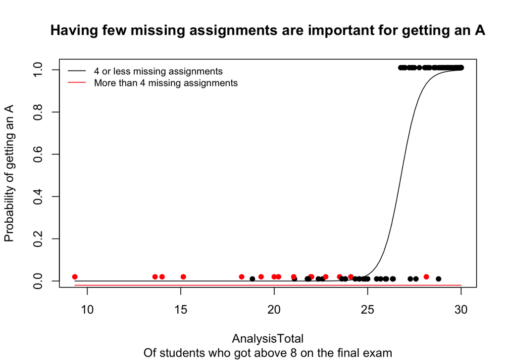

```r
final_above_8 <- grades %>%
  filter(FinalExam > 8)

plot(Y + as.numeric(zeros_four_or_greater)/100 ~ AnalysisTotal, data=final_above_8, pch=16, col=zeros_four_or_greater, ylab="Probability of getting an A", main="Having few missing assignments are important for getting an A", sub = "Of students who got above 8 on the final exam")

four_or_greater = 0; GoodFinal = 1;
curve(1/(exp(-b[1] - b[2]*x - b[3]*GoodFinal - b[4]*four_or_greater) + 1), add = TRUE, col="black")

four_or_greater = 1; GoodFinal = 1;
curve(1/(exp(-b[1] - b[2]*x - b[3]*GoodFinal - b[4]*four_or_greater) + 1) - .02, add = TRUE, col="red")

legend("topleft", legend=c("4 or less missing assignments", "More than 4 missing assignments"), bty="n", lty=1, col=c("black","red"), cex=0.8)
```

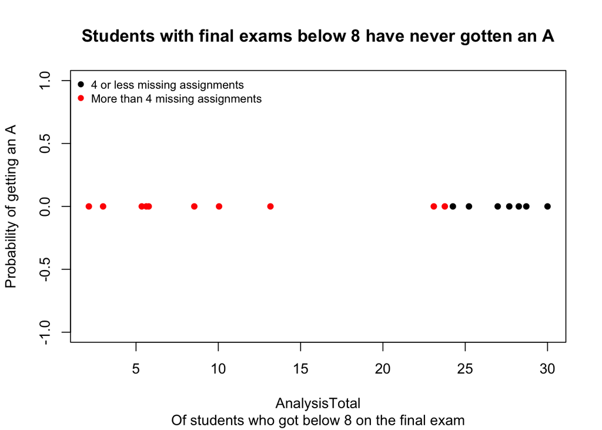

```r
final_below_8 <- grades %>%
  filter(FinalExam < 8)

plot(Y ~ AnalysisTotal, data=final_below_8, pch=16, col=zeros_four_or_greater, ylab="Probability of getting an A", main="Students with final exams below 8 have never gotten an A", sub = "Of students who got below 8 on the final exam")

legend("topleft", pch = 19, legend=c("4 or less missing assignments", "More than 4 missing assignments"), bty="n", col=c("black","red"), cex=0.8)
```

## Goodness of fit

The p-value from the goodness of fit test is .90 and the null hypothesis is that the model is a good fit. This leads me to not reject the null hypothesis and therfore conclude it is a good fit.

```r
hoslem.test(grades.glm$y, grades.glm$fitted.values)
```

```
##
##  Hosmer and Lemeshow goodness of fit (GOF) test
##
## data:  grades.glm$y, grades.glm$fitted.values
## X-squared = 3.3867, df = 8, p-value = 0.9078
```

## Validation

```r
dt_list <- split_df(grades, ratio = 0.70, seed = 100)

v.glm <- glm(Y ~ AnalysisTotal + good_final + zeros_four_or_greater, data = dt_list$test, family = binomial)

probabilities <- predict(v.glm, dt_list$test, type="response")
predictions <- ifelse(probabilities > .5, "A", "Other")

pander(table(predictions, dt_list$test$FinalGrade))
```

|  | A | Other |
| --- | --- | --- |
| **A** | 13 | 0 |
| **Other** | 0 | 23 |